# Predicción del Bajo Peso al Nacer en Guatemala con Modelos de Regresion y Clasificacion

Un enfoque de minería de datos para la salud pública

Mathew Cordero Aquino & Pablo Daniel Barillas Moreno

Universidad del Valle de Guatemala | Facultad de Ingeniería

Autor de correspondencia: bar22193@uvg.edu.gt

## Introducción

El bajo peso al nacer (BPN, <2500g) afecta al **12% de los nacimientos** en Guatemala (INE, 2022), con mayor prevalencia en áreas rurales e indígenas. La OMS busca reducir los casos en **30% para 2025**.

El objetivo de este estudio es desarrollar modelos predictivos de clasificación binaria y multiclase, evaluar el rendimiento de diferentes algoritmos de machine learning, identificar variables clave asociadas al bajo peso al nacer (BPN) en Guatemala y proponer herramientas que puedan contribuir a la formulación de políticas de salud materno-infantil.

### Resumen

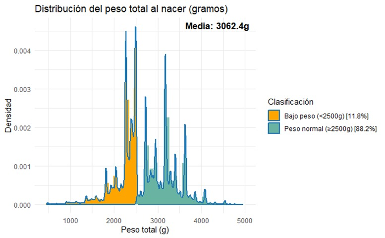

Figura 1: Distribución del peso al nacer en Guatemala (2009-2022), destacando casos de bajo peso (<2500g)

## Metodología

### Datos

**5+ millones de registros** del INE (2009-2022) incluyendo:

- Variables maternas (edad, ubicación)
- Tipo de parto y asistencia médica
- Historial reproductivo

### Preprocesamiento

- Limpieza e imputación de datos
- Balanceo con **SMOTE**
- Reducción dimensional con **PCA**

### Modelos Evaluados

- Naive Bayes (binario y multiclase)
- Regresión Logística
- Random Forest

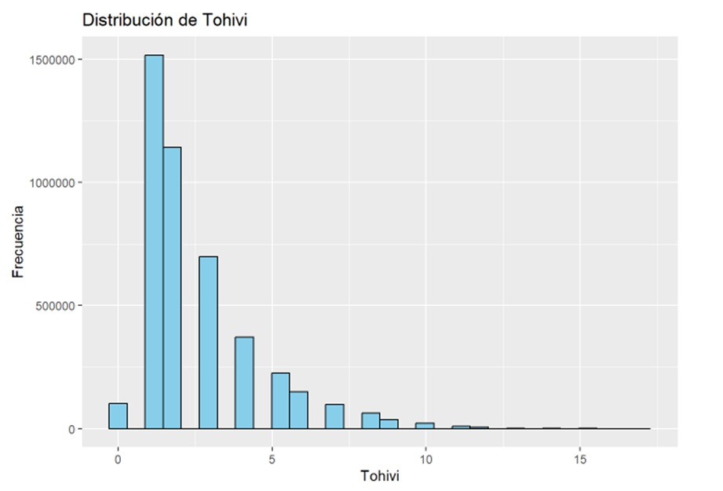

Figura 2: Distribución de hijos nacidos vivos por madre (variable más predictiva)

## Resultados Clave

#### Mejor desempeño predictivo

Tabla 1: Metricas de desempeño de modelos evaluados con peso_total_g

| Modelo | Accuracy | Sensibilidad | Precisión | AUC | RMSE |
| --- | --- | --- | --- | --- | --- |
| Naive Bayes Multiclase | 29.0% | 65.1% | 61.87% | - | - |
| Naive Bayes Binario | 88.67% | 6.5% | 74.46% | - | - |
| Naive Bayes Balanceado y PCA | 56.3% | 62.4% | 69% | 0.58 | - |
| Regresión Logística | 56.3% | 69.4% | - | 0.59 | - |
| Random Forest sin PCA | 55.1% | 62.5% | 62.51% | 0.58 | - |
| Random Forest PCA | 54.0% | 63.9% | 63.97% | 0.58 | - |
| Random Forest Validación Cruzada | 54.0% | 63.9% | 63.97% | 0.58 | - |
| Regresión Lineal 1 | - | - | - | - | 488.34 |
| Regresión Lineal 2 | - | - | - | - | 482.25 |
| Regresión Lineal 3 | - | - | - | - | 469.07 |

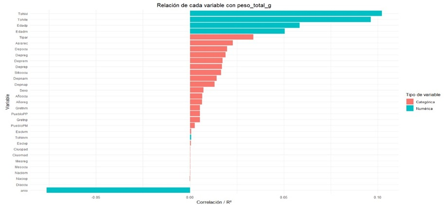

Figura 3: Correlación entre variables predictoras y peso al nacer

## Conclusiones y Recomendaciones

### Implicaciones

- La minería de datos puede identificar patrones de riesgo en salud pública
- El desbalance de clases requiere técnicas especializadas como SMOTE
- Se necesitan variables adicionales para mejorar la predictividad

### Recomendaciones

- Integrar modelos en sistemas del Ministerio de Salud
- Capacitar personal médico en interpretación predictiva
- Recolectar datos adicionales (educación, nutrición)

Peso al nacer Guatemala Naive Bayes Random Forest SMOTE Minería de datos Salud pública Clasificación multiclase PCA